# COVID-19 Case Study

## DATASCI 347

Xinmo Chen

Aadit Narayanan

Daniel Nickas

# 1) There are two main goals for this case study:

1. We show the dynamic evolvement of COVID cases and COVID-related death at state level.
2. We try to figure out what county-level demographic and policy interventions are associated with mortality rate in the US. We try to construct models to find possible factors related to county-level COVID-19 mortality rates.

# 2) Data Summary:

#### County-level infection and fatality data

- This dataset gives daily cumulative numbers on infection and fatality for each county.

#### County-level socioeconomic data

- The following are the four relevant datasets from this site:
  - Income - Poverty level and household income.
  - Jobs - Employment type, rate, and change.
  - People - Population size, density, education level, race, age, household size, and migration rates.
  - County Classifications - Type of county (rural or urban on a rural-urban continuum scale).

#### Intervention Policy Data

- This dataset is a manually compiled list of the dates that interventions/lockdown policies were implemented and lifted at the county level.

# 3) EDA:

### In this case study, we use the following three cleaned data:

##### covid_county.csv: County-level socioeconomic information that combines the above-mentioned

```
- 4 datasets Income, Jobs, People, and County Classifications
```

##### covid_rates.csv: Daily cumulative numbers on infection and fatality for each county

##### covid_intervention.csv: County-level lockdown intervention.

*Among all data, the unique identifier of county is FIPS.*

## 3.1) Understanding the Data

#### Covid County dataset (covid_county.csv):

Covid County concerns socioeconomic data ranging from the 2000s to the 2020s. A FIPS code (unique county identifier) acts as the join key to other datasets. Data related to population characterstics such as income, education, employment, race, location, location characteristics (metro vs. non metro areas) are crucial to finding what variables may (or may not) impact the effect of covid intervention policies. Socioeconomic variables from mixed sources/years have suppressed values for some counties, yielding scattered nulls across income, poverty, education, and related fields...this may be attributed to poor data recording or insufficient research. Structure of the data is shown below.

#### Intervention (covid_intervention.csv):

The Covid Intervention dataset is a county-level timeline of non-pharmaceutical COVID-19 policies. Each row records a policy event for a county (keyed by FIPS code) including the policy type (e.g., stay-at-home, school/business closures, gathering limits, mask mandates), the date it was implemented, and when it was lifted (noted as missing if still in effect at the time this data was finalized in this form). Counties can have multiple rows for different policy types or changes over time. Use FIPS to join to covid_rates and align by date ranges to construct policy exposure indicators and analyze associations with cases/deaths. Event records often lack lift (end) dates and some county-policy entries, so nulls indicate policies still in effect or unreported. Structure of data is shown below.

```python
# import packages
import pandas as pd
import numpy as np
from matplotlib.pyplot import subplots
from statsmodels.api import OLS
import sklearn.model_selection as skm
import sklearn.linear_model as skl
from sklearn.preprocessing import StandardScaler
from ISLP import load_data
from ISLP.models import ModelSpec as MS
from functools import partial
import matplotlib.pyplot as plt
```

```python
# County-level Socioeconomic data
covid_county = pd.read_csv('covid_county.csv')
print(covid_county)
print("data types:", covid_county.dtypes)
print("data summary:", covid_county.describe())
print("missing data:", covid_county.isnull().sum())
print(covid_county.info())
```

```
       FIPS State         County  MedHHInc  PerCapitaInc  PovertyUnder18Pct  \
0         0    US  United States   61937.0       32621.0               18.0
1      1000    AL        Alabama   49881.0       26846.0               23.9
2      1001    AL        Autauga   59338.0       29372.0               19.3
3      1003    AL        Baldwin   57588.0       31203.0               13.9
4      1005    AL        Barbour   34382.0       18461.0               43.9
...     ...   ...            ...       ...           ...                ...
3274  72147    PR        Vieques       NaN       11156.0                NaN
3275  72149    PR       Villalba       NaN       10677.0                NaN
3276  72151    PR        Yabucoa       NaN        9148.0                NaN
3277  72153    PR          Yauco       NaN        8339.0                NaN
3278  72153    PR          Yauco       NaN        8339.0                NaN

      PovertyAllAgesPct  Deep_Pov_All  Deep_Pov_Children  PovertyUnder18Num  \
0                  13.1      6.249590           8.598276         12997532.0
1                  16.8      7.611623          11.591313           255613.0
2                  13.8      6.142609           8.910594             2509.0
3                   9.8      4.482528           6.214526             6442.0
4                  30.9     12.749387          26.709797             2242.0
...                 ...           ...                ...                ...
3274                NaN     23.747851          63.160920                NaN
3275                NaN     24.167835          36.739088                NaN
3276                NaN     28.891108          42.151418                NaN
3277                NaN     27.181356          35.961619                NaN
3278                NaN     27.181356          35.961619                NaN

      ...  FarmDependent2003  ManufacturingDependent2000  LowEducation2000  \
0     ...                NaN                         NaN               NaN
1     ...                NaN                         NaN               NaN
2     ...                0.0                         1.0               0.0
3     ...                0.0                         0.0               0.0
4     ...                0.0                         1.0               1.0
...   ...                ...                         ...               ...
3274  ...                NaN                         NaN               NaN
3275  ...                NaN                         NaN               NaN
3276  ...                NaN                         NaN               NaN
3277  ...                NaN                         NaN               NaN
3278  ...                NaN                         NaN               NaN

      RetirementDestination2000  PersistentPoverty2000  Noncore2013  \
```

[output cut: 125 more lines]

```
MedHHInc                        86
PerCapitaInc                     6
                              ...
Noncore2013                     57
Type_2015_Nonspecialized_NO    136
Metro_Adjacent2013              57
PersistentChildPoverty2004     138
RecreationDependent2000        138
Length: 208, dtype: int64
<class 'pandas.core.frame.DataFrame'>
RangeIndex: 3279 entries, 0 to 3278
Columns: 208 entries, FIPS to RecreationDependent2000
dtypes: float64(205), int64(1), object(2)
memory usage: 5.2+ MB
None
```

```python
# County level infection data
covid_rates = pd.read_csv("covid_rates.csv")
print(covid_rates)
print("data types:", covid_rates.dtypes)
print("data summary:", covid_rates.describe())
print("missing data:", covid_rates.isnull().sum)
print(covid_rates.info())
```

```
          FIPS        date   County        State  cum_cases  cum_deaths  week  \
0        10001  2020-03-18     Kent     Delaware          3           0     9
1        10001  2020-03-19     Kent     Delaware          4           0     9
2        10001  2020-03-20     Kent     Delaware          4           0     9
3        10001  2020-03-21     Kent     Delaware          5           0     9
4        10001  2020-03-22     Kent     Delaware          5           0    10
...        ...         ...      ...          ...        ...         ...   ...
1008979   9015  2021-02-16  Windham  Connecticut       8963         172    57
1008980   9015  2021-02-17  Windham  Connecticut       8974         174    57
1008981   9015  2021-02-18  Windham  Connecticut       8976         174    57
1008982   9015  2021-02-19  Windham  Connecticut       9028         176    57
1008983   9015  2021-02-20  Windham  Connecticut       9028         176    57

         TotalPopEst2019
0                 180786
1                 180786
2                 180786
3                 180786
4                 180786
...                  ...
1008979           116782
1008980           116782
1008981           116782
1008982           116782
1008983           116782

[1008984 rows x 8 columns]
data types: FIPS                int64
date               object
County             object
State              object
cum_cases           int64
cum_deaths          int64
week                int64
TotalPopEst2019     int64
dtype: object
data summary:                FIPS     cum_cases    cum_deaths          week  TotalPopEst2019
count  1.008984e+06  1.008984e+06  1.008984e+06  1.008984e+06     1.008984e+06
mean   3.057170e+04  2.932837e+03  6.558753e+01  3.412985e+01     1.124047e+05
std    1.505423e+04  1.474719e+04  3.229540e+02  1.364022e+01     3.566328e+05
```

[output cut: 33 more lines]

```
RangeIndex: 1008984 entries, 0 to 1008983
Data columns (total 8 columns):
 #   Column           Non-Null Count    Dtype
---  ------           --------------    -----
 0   FIPS             1008984 non-null  int64
 1   date             1008984 non-null  object
 2   County           1008984 non-null  object
 3   State            1008984 non-null  object
 4   cum_cases        1008984 non-null  int64
 5   cum_deaths       1008984 non-null  int64
 6   week             1008984 non-null  int64
 7   TotalPopEst2019  1008984 non-null  int64
dtypes: int64(5), object(3)
memory usage: 61.6+ MB
None
```

```python
# Intervention policy csv
intervention = pd.read_csv("covid_intervention.csv")
print(intervention)
print("data types:", intervention.dtypes)
print("data summary:", intervention.describe())
print("missing data:", intervention.isnull().sum())
print(intervention.info())
```

```
       FIPS STATE                         AREA_NAME stay at home  \
0      1000    AL                           alabama   2020-04-05
1      1001    AL                    autauga county   2020-04-05
2      1003    AL                    baldwin county   2020-04-05
3      1005    AL                    barbour county   2020-04-05
4      1007    AL                       bibb county   2020-04-05
...     ...   ...                               ...          ...
3267  72145    PR  vega baja municipio, puerto rico          NaN
3268  72147    PR    vieques municipio, puerto rico          NaN
3269  72149    PR   villalba municipio, puerto rico          NaN
3270  72151    PR    yabucoa municipio, puerto rico          NaN
3271  72153    PR      yauco municipio, puerto rico          NaN

     >50 gatherings >500 gatherings public schools restaurant dine-in  \
0        2020-03-21      2020-03-14     2020-03-17         2020-03-20
1        2020-03-21      2020-03-14     2020-03-17         2020-03-20
2        2020-03-21      2020-03-14     2020-03-17         2020-03-20
3        2020-03-21      2020-03-14     2020-03-17         2020-03-20
4        2020-03-21      2020-03-14     2020-03-17         2020-03-20
...             ...             ...            ...                ...
3267            NaN             NaN     2020-03-17         2020-03-16
3268            NaN             NaN     2020-03-17         2020-03-16
3269            NaN             NaN     2020-03-17         2020-03-16
3270            NaN             NaN     2020-03-17         2020-03-16
3271            NaN             NaN     2020-03-17         2020-03-16

     entertainment/gym federal guidelines foreign travel ban  \
0           2020-03-29         2020-03-17         2020-03-12
1           2020-03-29         2020-03-17         2020-03-12
2           2020-03-29         2020-03-17         2020-03-12
3           2020-03-29         2020-03-17         2020-03-12
4           2020-03-29         2020-03-17         2020-03-12
...                ...                ...                ...
3267        2020-03-16         2020-03-17         2020-03-12
3268        2020-03-16         2020-03-17         2020-03-12
3269        2020-03-16         2020-03-17         2020-03-12
3270        2020-03-16         2020-03-17         2020-03-12
3271        2020-03-16         2020-03-17         2020-03-12

     stay at home rollback >50 gatherings rollback >500 gatherings rollback  \
```

[output cut: 78 more lines]

```
 4   >50 gatherings               3072 non-null   object
 5   >500 gatherings              3072 non-null   object
 6   public schools               3272 non-null   object
 7   restaurant dine-in           3272 non-null   object
 8   entertainment/gym            3205 non-null   object
 9   federal guidelines           3272 non-null   object
 10  foreign travel ban           3272 non-null   object
 11  stay at home rollback        2668 non-null   object
 12  >50 gatherings rollback      1252 non-null   object
 13  >500 gatherings rollback     1042 non-null   object
 14  restaurant dine-in rollback  2848 non-null   object
 15  entertainment/gym rollback   2708 non-null   object
dtypes: int64(1), object(15)
memory usage: 409.1+ KB
None
```

## 3.2 COVID case trend)

It is crucial to decide the right granularity for visualization and analysis. We will compare daily vs weekly total new cases by state and we will see it is hard to interpret daily report.

#### i) Plot new COVID cases in NY, WA and FL by state and by day. Any irregular pattern? What is the biggest problem of using single day data?

There are noticeable spikes/irregularities around holidays and "miscellaneous non-working periods." For example, Christmas and New Years periods show extreme single day spikes as compared to the rest of the data. Additionally single day data are noisy as they are purely the result of reporting data which is a lagging statistic (not completely up to date nor exact). A better alternative is to use weekly or monthly averages or totals.

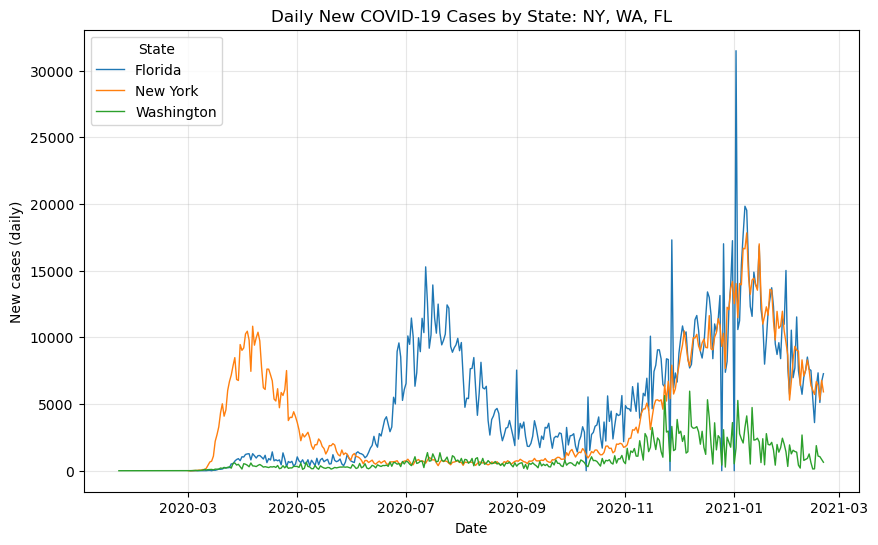

```python
covid_rates['date'] = pd.to_datetime(covid_rates['date'], errors='coerce')

cases_state_daily = (
    covid_rates
    .groupby(['State', 'date'], as_index=False)['cum_cases']
    .sum()
    .sort_values(['State', 'date'])
)
cases_state_daily['new_cases'] = cases_state_daily.groupby('State')['cum_cases'].diff()


state_targets = ['New York', 'Washington', 'Florida']

plot_df = cases_state_daily[
    cases_state_daily['State'].isin(state_targets)
].dropna(subset=['new_cases'])


fig, ax = subplots(figsize=(10, 6))
for st, sdf in plot_df.groupby('State'):
    ax.plot(sdf['date'], sdf['new_cases'], label=st, linewidth=1.0)

ax.set_title('Daily New COVID-19 Cases by State: NY, WA, FL')
ax.set_xlabel('Date')
ax.set_ylabel('New cases (daily)')
ax.legend(title='State')
ax.grid(alpha=0.3)
```

#### ii) Create weekly new cases per 100k weekly case per100k. Plot the spaghetti plots of weekly case per100k by state. Use TotalPopEst2019 as population.

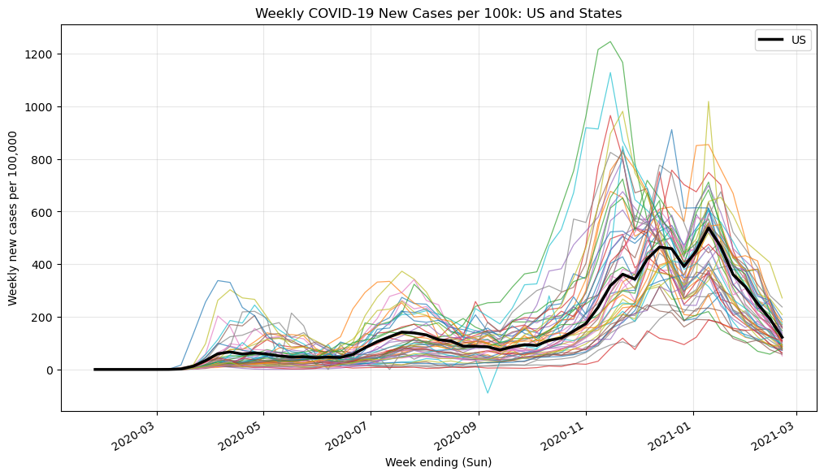

```python
covid_rates['date'] = pd.to_datetime(covid_rates['date'], errors='coerce')
covid_rates['State'] = covid_rates['State'].astype(str).str.strip()
covid_rates['cum_cases'] = pd.to_numeric(covid_rates['cum_cases'], errors='coerce')

# Daily new cases at state level
cases_state_daily = (
    covid_rates
    .groupby(['State', 'date'], as_index=False)['cum_cases']
    .sum()
    .sort_values(['State', 'date'])
)
cases_state_daily['new_cases'] = (
    cases_state_daily
    .groupby('State')['cum_cases']
    .diff()
)

state_weekly = (
    cases_state_daily
    .groupby(['State', pd.Grouper(key='date', freq='W-SUN')], as_index=False)['new_cases']
    .sum()
    .rename(columns={'date': 'week_end', 'new_cases': 'weekly_new_cases'})
)


county_pop = (
    covid_rates[['FIPS', 'State', 'TotalPopEst2019']]
    .dropna(subset=['FIPS', 'TotalPopEst2019'])
    .drop_duplicates(subset=['FIPS'])
    .groupby('State', as_index=False)['TotalPopEst2019']
    .sum()
)


state_weekly = state_weekly.merge(county_pop, on='State', how='left')
state_weekly['weekly_per100k'] = (
    state_weekly['weekly_new_cases'] / state_weekly['TotalPopEst2019']
) * 1e5

us_weekly = (
    state_weekly
    .groupby('week_end', as_index=False)
    .agg(weekly_new_cases=('weekly_new_cases', 'sum'),
         population=('TotalPopEst2019', 'sum'))
)
us_weekly['weekly_per100k'] = (us_weekly['weekly_new_cases'] / us_weekly['population']) * 1e5



fig, ax = subplots(figsize=(12, 7))
for st, sdf in state_weekly.dropna(subset=['weekly_per100k']).groupby('State'):
    ax.plot(sdf['week_end'], sdf['weekly_per100k'], linewidth=0.9, alpha=0.7)
ax.plot(us_weekly['week_end'], us_weekly['weekly_per100k'], color='black', linewidth=2.5, label='US')

ax.set_title('Weekly COVID-19 New Cases per 100k: US and States')
ax.set_xlabel('Week ending (Sun)')
ax.set_ylabel('Weekly new cases per 100,000')
ax.legend()
ax.grid(alpha=0.3)
fig.autofmt_xdate()
plt.show()
```

### iii) Summarize the COVID case trend among states based on the plot in ii). What could be the possible reasons to explain the variabilities?

Generally, holiday seasons/travel seasons such as beginning of July, end of November, December, and early January, show notable spikes in cases per 100k people. One may infer from Covid-19 reporting that during these times (when people often get together in larger groups outside of immediate family) Covid-19 cases increased per 100k weekly.

**Variability of case rates within states can depend on:**

```
- Timing of introductions and community transmission by region
- Population density/urbanization and contact patterns.
- Mobility and behavior changes (holidays mentioned above, business/school closing/reopening).
- Policy implementation (mask mandates, social distancing, etc.)
- Demographics
- Variant types
```

#### iv) (Optional) Use covid intervention to see whether the effectiveness of lockdown in flattening the curve.

## 3.3 COVID death trend

#### i) For each month in 2020, plot the monthly deaths per 100k heatmap by state on US map.

Use the same color range across months.

(Hints: Set limits in matplotlib.pyplot.clim() or use seaborn.FacetGrid(); use pandas.to datetime() with .dt.month and .dt.year to extract month and year from date; use pandas.DataFrame.merge() with appropriate parameters to complete the missing months with no cases.)

```python
import plotly.express as px

covid_rates['date'] = pd.to_datetime(covid_rates['date'], errors='coerce')
covid_rates['State'] = covid_rates['State'].astype(str).str.strip()
covid_rates['cum_deaths'] = pd.to_numeric(covid_rates['cum_deaths'], errors='coerce')
covid_rates['TotalPopEst2019'] = pd.to_numeric(covid_rates['TotalPopEst2019'], errors='coerce')


state_pop = (
    covid_rates[['FIPS', 'State', 'TotalPopEst2019']]
    .dropna(subset=['FIPS', 'TotalPopEst2019'])
    .drop_duplicates(subset=['FIPS'])
    .groupby('State', as_index=False)['TotalPopEst2019']
    .sum()
    .rename(columns={'TotalPopEst2019': 'state_pop_2019'})
)


state_daily_deaths = (
    covid_rates
    .groupby(['State', 'date'], as_index=False)['cum_deaths']
    .sum()
    .sort_values(['State', 'date'])
)
state_daily_deaths['new_deaths'] = (
    state_daily_deaths
    .groupby('State')['cum_deaths']
    .diff()
    .clip(lower=0)
)

monthly_deaths = (
    state_daily_deaths
    .loc[state_daily_deaths['date'].dt.year == 2020]
    .groupby(['State', pd.Grouper(key='date', freq='MS')], as_index=False)['new_deaths']
    .sum()
    .rename(columns={'date': 'month_start', 'new_deaths': 'monthly_deaths'})
)


all_states = state_pop['State'].unique()
all_months = pd.date_range('2020-01-01', '2020-12-01', freq='MS')
complete = (
    pd.MultiIndex.from_product([all_states, all_months], names=['State', 'month_start'])
    .to_frame(index=False)
)
monthly_deaths = (
    complete
    .merge(monthly_deaths, on=['State', 'month_start'], how='left')
    .fillna({'monthly_deaths': 0})
)


monthly_deaths = monthly_deaths.merge(state_pop, on='State', how='left')
monthly_deaths['deaths_per100k'] = (monthly_deaths['monthly_deaths'] / monthly_deaths['state_pop_2019']) * 1e5
monthly_deaths['month'] = monthly_deaths['month_start'].dt.month

# State name -> USPS code (for Plotly)
state_to_abbr = {
    'Alabama':'AL','Alaska':'AK','Arizona':'AZ','Arkansas':'AR','California':'CA','Colorado':'CO',
    'Connecticut':'CT','Delaware':'DE','District of Columbia':'DC','Florida':'FL','Georgia':'GA',
    'Hawaii':'HI','Idaho':'ID','Illinois':'IL','Indiana':'IN','Iowa':'IA','Kansas':'KS',
    'Kentucky':'KY','Louisiana':'LA','Maine':'ME','Maryland':'MD','Massachusetts':'MA',
    'Michigan':'MI','Minnesota':'MN','Mississippi':'MS','Missouri':'MO','Montana':'MT',
    'Nebraska':'NE','Nevada':'NV','New Hampshire':'NH','New Jersey':'NJ','New Mexico':'NM',
    'New York':'NY','North Carolina':'NC','North Dakota':'ND','Ohio':'OH','Oklahoma':'OK',
    'Oregon':'OR','Pennsylvania':'PA','Rhode Island':'RI','South Carolina':'SC',
    'South Dakota':'SD','Tennessee':'TN','Texas':'TX','Utah':'UT','Vermont':'VT',
    'Virginia':'VA','Washington':'WA','West Virginia':'WV','Wisconsin':'WI','Wyoming':'WY'
}
monthly_deaths['state_abbr'] = monthly_deaths['State'].map(state_to_abbr)

vmax = monthly_deaths['deaths_per100k'].max()

fig = px.choropleth(
    monthly_deaths,
    locations='state_abbr',
    locationmode='USA-states',
    color='deaths_per100k',
    scope='usa',
    facet_col='month',
    facet_col_wrap=4,
    category_orders={'month': list(range(1, 13))},
    color_continuous_scale='Reds',
    range_color=(0, vmax),
    labels={'deaths_per100k': 'Deaths per 100k'},
    title='Monthly COVID-19 Deaths per 100k by State (2020)'
)
fig.update_layout(coloraxis_colorbar_title='Deaths/100k', margin=dict(l=10, r=10, t=60, b=10))
fig.show()
```

[output not shown]

ii) (Optional) Use plotly to animate the monthly maps in i). Does it reveal any systematic way to capture the dynamic changes among states? (Hints: Use plotly.express.choropleth() with animation frame argument for animation. Plotly recognizes state abbreviations for map- ping.)

# 4) COVID Factors:

```python
import pandas as pd
import numpy as np
import matplotlib.pyplot as plt
from scipy import stats
import statsmodels.api as sm
from statsmodels.stats.outliers_influence import variance_inflation_factor
from statsmodels.stats.diagnostic import het_breuschpagan
from statsmodels.nonparametric.smoothers_lowess import lowess

county = pd.read_csv("covid_county.csv")
rates = pd.read_csv("covid_rates.csv")
county.columns = county.columns.str.strip().str.lower()
rates.columns = rates.columns.str.strip().str.lower()
rates = rates.rename(columns={"cum_deaths": "deaths", "cum_cases": "cases"})
rates["date"] = pd.to_datetime(rates["date"], errors="coerce")
for df in (county, rates):
    df["fips"] = pd.to_numeric(df["fips"], errors="coerce").astype("Int64")
cutoff = pd.Timestamp("2021-02-01")
rates_feb1 = rates[rates["date"] <= cutoff]
total_deaths = (rates_feb1.groupby("fips", dropna=False)["deaths"].max().reset_index())
merged = county.merge(total_deaths, on="fips", how="left")
merged["deaths"] = merged["deaths"].fillna(0)
merged["totalpopest2019"] = merged["totalpopest2019"].replace({0: np.nan})
merged["total_death_per100k"] = (merged["deaths"] / merged["totalpopest2019"]) * 100000
merged["log_total_death_per100k"] = np.log(merged["total_death_per100k"].fillna(0) + 1)
merged = merged[merged["fips"].notna() &(merged["fips"] >= 1000) & (merged["fips"] % 1000 != 0) &(merged["state"] != "US")]
print(merged[["fips", "state", "deaths", "total_death_per100k", "log_total_death_per100k"]].head())
print("\nNumber of counties:", len(merged))
```

```
   fips state  deaths  total_death_per100k  log_total_death_per100k
2  1001    AL    69.0           123.503195                 4.824331
3  1003    AL   225.0           100.791098                 4.622923
4  1005    AL    40.0           162.035162                 5.093966
5  1007    AL    52.0           232.205055                 5.451918
6  1009    AL   100.0           172.932591                 5.158668

Number of counties: 3226
```

```python
selected_vars = [
    "state", "fips",
    "under18pct2010",
    "percapitainc",
    "avghhsize",
    "popdensity2010",
    "unemprate2019",
    "log_total_death_per100k"
]
available = [c for c in selected_vars if c in merged.columns]
county_data_sub = merged[available].copy()
print("Subset shape:", county_data_sub.shape)
print(county_data_sub.head())
missing = county_data_sub.isna().sum().reset_index()
missing.columns = ["variable", "num_missing"]
missing["percent_missing"] = 100 * missing["num_missing"] / len(county_data_sub)
print("\nMissing value summary:")
print(missing.sort_values("percent_missing", ascending=False))
```

```
Subset shape: (3226, 8)
  state  fips  under18pct2010  percapitainc  avghhsize  popdensity2010  \
2    AL  1001           26.78       29372.0       2.59           91.80
3    AL  1003           22.99       31203.0       2.61          114.65
4    AL  1005           21.91       18461.0       2.49           31.03
5    AL  1007           22.70       20199.0       2.99           36.81
6    AL  1009           24.61       22656.0       2.77           88.90

   unemprate2019  log_total_death_per100k
2            2.7                 4.824331
3            2.7                 4.622923
4            3.8                 5.093966
5            3.1                 5.451918
6            2.7                 5.158668

Missing value summary:
                  variable  num_missing  percent_missing
3             percapitainc            6         0.185989
6            unemprate2019            6         0.185989
2           under18pct2010            5         0.154991
4                avghhsize            5         0.154991
5           popdensity2010            5         0.154991
0                    state            0         0.000000
1                     fips            0         0.000000
7  log_total_death_per100k            0         0.000000
```

```python
from sklearn.preprocessing import StandardScaler
from sklearn.linear_model import LinearRegression, LassoCV
from sklearn.pipeline import make_pipeline

sub = county_data_sub.dropna().copy()
y = sub["log_total_death_per100k"].to_numpy()
X_state = pd.get_dummies(sub["state"], drop_first=True)
num_cols = ["under18pct2010", "percapitainc", "avghhsize", "popdensity2010", "unemprate2019"]
X_num = sub[num_cols].copy()

ols_state = LinearRegression(fit_intercept=True)
ols_state.fit(X_state, y)
y_hat_state = ols_state.predict(X_state)
y_resid = y - y_hat_state

lasso = make_pipeline(StandardScaler(with_mean=True, with_std=True),LassoCV(cv=10, random_state=0, n_alphas=100, max_iter=100000))
lasso.fit(X_num, y_resid)

lasso_cv = lasso.named_steps["lassocv"]
coef_series = pd.Series(lasso_cv.coef_, index=num_cols)

print("LASSO results on residuals (with State)")
print(f"Best alpha (lambda): {lasso_cv.alpha_:.6f}")
print("Coefficients (standardized scale):")
print(coef_series)
```

```
LASSO results on residuals (with State)
Best alpha (lambda): 0.005911
Coefficients (standardized scale):
under18pct2010    0.110875
percapitainc     -0.126883
avghhsize        -0.096121
popdensity2010    0.052608
unemprate2019    -0.000000
dtype: float64
```

### iv

We need to force in state because otherwise we are not controlling for macro impacts like economic, social, and healthcare policies.

```python
import numpy as np
y_hat_resid = lasso.predict(X_num)
y_hat_total = y_hat_state + y_hat_resid
resid = y - y_hat_total
n = len(y)
p = np.sum(lasso_cv.coef_ != 0) + X_state.shape[1] + 1
RSS = np.sum(resid ** 2)
sigma2_hat = RSS / (n - p)
Cp = RSS / sigma2_hat - n + 2 * p
print(f"Mallows' Cp: {Cp}")
```

```
Mallows' Cp: 56.0
```

```python
num_active = np.sum(lasso_cv.coef_ != 0)
state_active = X_state.shape[1]
p_effective = num_active + state_active + 1
print(f"Active numeric vars: {num_active}")
print(f"State dummy vars: {state_active}")
print(f"Effective parameter count (p): {p_effective}")
```

```
Active numeric vars: 4
State dummy vars: 51
Effective parameter count (p): 56
```

The model cannot be optimized further since p = Cp.

```
Coefficients for numeric variables:
under18pct2010      :   0.050609  (p=0.0000) ***
percapitainc        :  -0.000032  (p=0.0000) ***
avghhsize           :  -0.509862  (p=0.0000) ***
popdensity2010      :   0.000041  (p=0.0000) ***

All variables significant at 0.05: True
R-squared: 0.6192
Adjusted R-squared: 0.6126

Model Assumptions:
Shapiro-Wilk test: W=0.7810, p=0.0000
Breusch-Pagan test: stat=364.9308, p=0.0000

Variance Inflation Factors:
under18pct2010      : 88.57
percapitainc        : 12.00
avghhsize           : 94.52
popdensity2010      : 1.07
```

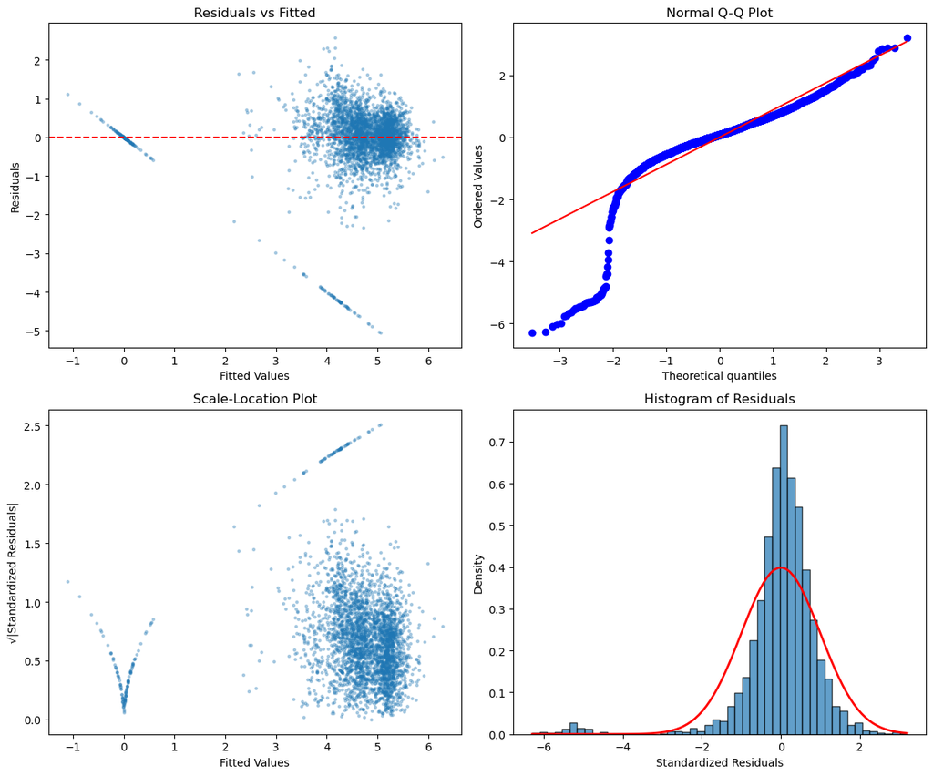

```python
selected_vars = [
    "state", "fips", "under18pct2010", "percapitainc", "avghhsize",
    "popdensity2010", "age65andolderpct2010", "blacknonhispanicpct2010",
    "hispanicpct2010", "log_total_death_per100k"
]

available = [c for c in selected_vars if c in merged.columns]
sub = merged[available].dropna().copy()

y = sub["log_total_death_per100k"].values
X_state = pd.get_dummies(sub["state"], drop_first=True, dtype=float)

significant_vars = ["under18pct2010", "percapitainc", "avghhsize", "popdensity2010"]
X_num = sub[significant_vars].copy()

X_full = pd.concat([X_state, X_num], axis=1)
X_full = sm.add_constant(X_full)

model = sm.OLS(y, X_full)
results = model.fit()

print("\nCoefficients for numeric variables:")
for var in significant_vars:
    coef = results.params[var]
    pval = results.pvalues[var]
    sig = "***" if pval < 0.001 else "**" if pval < 0.01 else "*" if pval < 0.05 else ""
    print(f"{var:20s}: {coef:10.6f}  (p={pval:.4f}) {sig}")

print(f"\nAll variables significant at 0.05: {all(results.pvalues[var] < 0.05 for var in significant_vars)}")
print(f"R-squared: {results.rsquared:.4f}")
print(f"Adjusted R-squared: {results.rsquared_adj:.4f}")

y_pred = results.fittedvalues
residuals = results.resid
standardized_residuals = residuals / np.sqrt(results.scale)

fig, axes = plt.subplots(2, 2, figsize=(12, 10))

axes[0, 0].scatter(y_pred, residuals, alpha=0.3, s=5)
axes[0, 0].axhline(y=0, color='r', linestyle='--')
axes[0, 0].set_xlabel('Fitted Values')
axes[0, 0].set_ylabel('Residuals')
axes[0, 0].set_title('Residuals vs Fitted')

stats.probplot(standardized_residuals, dist="norm", plot=axes[0, 1])
axes[0, 1].set_title('Normal Q-Q Plot')

sqrt_abs_resid = np.sqrt(np.abs(standardized_residuals))
axes[1, 0].scatter(y_pred, sqrt_abs_resid, alpha=0.3, s=5)
axes[1, 0].set_xlabel('Fitted Values')
axes[1, 0].set_ylabel('√|Standardized Residuals|')
axes[1, 0].set_title('Scale-Location Plot')

axes[1, 1].hist(standardized_residuals, bins=50, density=True, alpha=0.7, edgecolor='black')
x_range = np.linspace(standardized_residuals.min(), standardized_residuals.max(), 100)
axes[1, 1].plot(x_range, stats.norm.pdf(x_range, 0, 1), 'r-', linewidth=2)
axes[1, 1].set_xlabel('Standardized Residuals')
axes[1, 1].set_ylabel('Density')
axes[1, 1].set_title('Histogram of Residuals')

plt.tight_layout()

print("\nModel Assumptions:")

sample_size = min(5000, len(residuals))
shapiro_stat, shapiro_p = stats.shapiro(residuals[:sample_size])
print(f"Shapiro-Wilk test: W={shapiro_stat:.4f}, p={shapiro_p:.4f}")

bp_stat, bp_p, _, _ = het_breuschpagan(residuals, X_full)
print(f"Breusch-Pagan test: stat={bp_stat:.4f}, p={bp_p:.4f}")


print("\nVariance Inflation Factors:")
for i, var in enumerate(significant_vars):
    vif = variance_inflation_factor(X_num.values, i)
    print(f"{var:20s}: {vif:.2f}")
```

### xi

```python
demo_vars = ["age65andolderpct2010", "blacknonhispanicpct2010", "hispanicpct2010"]
available_demo = [v for v in demo_vars if v in sub.columns]

if available_demo:
    # Add demographic variables to model
    X_demo = sub[available_demo].copy()
    X_extended = pd.concat([X_state, X_num, X_demo], axis=1)
    X_extended = sm.add_constant(X_extended)

    model_extended = sm.OLS(y, X_extended)
    results_extended = model_extended.fit()

    print("\nDemographic Variables Analysis:")
    for var in available_demo:
        coef = results_extended.params[var]
        pval = results_extended.pvalues[var]
        sig = "***" if pval < 0.001 else "**" if pval < 0.01 else "*" if pval < 0.05 else ""
        print(f"\n{var}:")
        print(f"  Coefficient: {coef:10.6f}")
        print(f"  P-value: {pval:.4f} {sig}")

        if "age65" in var.lower():
            if pval < 0.05:
                direction = "higher" if coef > 0 else "lower"
                print(f"  Interpretation: Higher elderly population → {direction} death rates")
                print(f"  Supports claim: {'Yes' if coef > 0 else 'No'}")
            else:
                print(f"  Interpretation: No significant effect found")

        if "black" in var.lower():
            if pval < 0.05:
                direction = "higher" if coef > 0 else "lower"
                print(f"  Interpretation: Higher Black population → {direction} death rates")
                print(f"  Supports claim: {'Yes' if coef > 0 else 'No'}")
            else:
                print(f"  Interpretation: No significant effect found")

        if "hispanic" in var.lower():
            if pval < 0.05:
                direction = "higher" if coef > 0 else "lower"
                print(f"  Interpretation: Higher Hispanic population → {direction} death rates")
                print(f"  Supports claim: {'Yes' if coef > 0 else 'No'}")
            else:
                print(f"  Interpretation: No significant effect found")
else:
    print("\nDemographic variables not found in dataset.")
    print("Add these variables to analyze elderly and racial disparities.")
```

```
Demographic Variables Analysis:

age65andolderpct2010:
  Coefficient:   0.030615
  P-value: 0.0000 ***
  Interpretation: Higher elderly population → higher death rates
  Supports claim: Yes

blacknonhispanicpct2010:
  Coefficient:   0.005329
  P-value: 0.0006 ***
  Interpretation: Higher Black population → higher death rates
  Supports claim: Yes
  Interpretation: Higher Hispanic population → higher death rates
  Supports claim: Yes

hispanicpct2010:
  Coefficient:   0.009227
  P-value: 0.0000 ***
  Interpretation: Higher Hispanic population → higher death rates
  Supports claim: Yes
```

### xii

The analysis strongly supports both claims about COVID-19's disproportionate impact on elderly and minority populations. For the elderly, we see a significant positive coefficient (0.0306, p < 0.0001) for the percentage of population 65 and older, meaning counties with higher elderly populations experienced significantly higher death rates even after controlling for state-level differences and other factors. This confirms that COVID does indeed affect elderly people more severely.

For racial disparities, the results also support the claims about African Americans and Latinx communities. Counties with higher percentages of Black residents show significantly higher death rates (coefficient = 0.0053, p = 0.0006), and the effect is even stronger for Hispanic populations (coefficient = 0.0092, p < 0.0001). Both of these positive coefficients indicate that counties with larger proportions of these minority groups experienced worse COVID outcomes. This likely reflects underlying structural inequalities like differences in healthcare access, occupational exposure, housing density, and pre-existing health conditions.

```python
print("\nModel Performance:")
print(f"  R-squared: {results.rsquared:.4f}")
print(f"  Adjusted R-squared: {results.rsquared_adj:.4f}")
print(f"  N = {int(results.nobs)}")

print("\nKey Findings (County-level factors):")
for var in significant_vars:
    coef = results.params[var]
    if "under18pct" in var:
        print(f"  • Higher youth population → Higher death rates (coef={coef:.4f})")
    elif "percapitainc" in var:
        print(f"  • Higher income → Lower death rates (coef={coef:.4f})")
    elif "avghhsize" in var:
        print(f"  • Larger households → Lower death rates (coef={coef:.4f})")
    elif "popdensity" in var:
        print(f"  • Higher density → Higher death rates (coef={coef:.4f})")

print("\nState Effects:")
print("  State fixed effects control for:")
print("    - Healthcare system differences")
print("    - State policy interventions")
print("    - Testing/reporting practices")
print("    - Cultural/behavioral factors")

# Top/bottom states
state_effects = {}
for col in X_state.columns:
    if col in results.params.index:
        state_effects[col] = results.params[col]

if state_effects:
    sorted_states = sorted(state_effects.items(), key=lambda x: x[1], reverse=True)
    print("\n  States with highest death rates (vs baseline):")
    for state, effect in sorted_states[:5]:
        print(f"    {state}: {effect:+.4f}")
    print("\n  States with lowest death rates (vs baseline):")
    for state, effect in sorted_states[-5:]:
        print(f"    {state}: {effect:+.4f}")
```

```
Model Performance:
  R-squared: 0.6192
  Adjusted R-squared: 0.6126
  N = 3220

Key Findings (County-level factors):
  • Higher youth population → Higher death rates (coef=0.0506)
  • Higher income → Lower death rates (coef=-0.0000)
  • Larger households → Lower death rates (coef=-0.5099)
  • Higher density → Higher death rates (coef=0.0000)

State Effects:
  State fixed effects control for:
    - Healthcare system differences
    - State policy interventions
    - Testing/reporting practices
    - Cultural/behavioral factors

  States with highest death rates (vs baseline):
    NJ: +5.5184
    CT: +5.2918
    DC: +5.2617
    MA: +5.1362
    SD: +5.1043

  States with lowest death rates (vs baseline):
    ME: +3.1893
    UT: +3.1641
    VT: +2.3895
    HI: +0.3317
    PR: -0.7108
```

### xiii

Our final model explains about 62% of the variation in COVID death rates across counties, which is pretty solid for this type of analysis. Looking at the county-level factors, we found some interesting patterns. Counties with higher percentages of youth actually had higher death rates, which seems counterintuitive at first but might reflect multigenerational households or essential worker demographics. Higher per capita income was protective against COVID deaths, likely because wealthier counties had better healthcare access and more ability to work from home. Larger household sizes were also associated with lower death rates, and higher population density led to higher death rates, which makes sense given how the virus spreads.

The state effects are really important here because they capture all the policy and systemic differences between states that we can't measure directly, things like how aggressively states locked down, mask mandates, healthcare system quality, and even cultural attitudes toward the pandemic. New Jersey, Connecticut, DC, Massachusetts, and South Dakota had the highest death rates relative to the baseline, while Hawaii, Puerto Rico, Vermont, Utah, and Maine performed the best. This variation suggests that state-level responses and conditions mattered a lot, independent of county demographics.

Based on these findings, policymakers should focus economic relief on low-income areas since income was clearly protective. High-density urban counties need extra resources since they're at higher risk. We should also look at what states like Hawaii and Vermont did right and try to replicate those strategies elsewhere. Finally, ensuring healthcare access in underserved counties is critical since that's likely driving some of the income and demographic effects we're seeing.

### ix

There are several ways we could improve this model. Right now we're just looking at a snapshot of total deaths by February 2021, but COVID evolved over time with different waves, variants, and vaccination rollout. A time-series or panel data approach would let us see how factors changed over the pandemic and capture the effects of interventions as they happened. We should also test for interaction effects, like maybe population density matters more in states with weaker policies, or income effects differ by age distribution. The model also assumes linear relationships, but reality might be more complex with threshold effects or diminishing returns. Finally, we're probably missing spatial autocorrelation since nearby counties likely influenced each other through travel and shared resources.